# Ejercicios Prácticos: Campos Vectoriales y Puntos de Equilibrio en R

Manus AI

23 de marzo de 2026

# Análisis Gráfico de Sistemas Dinámicos en R

En esta clase práctica, aprenderemos a visualizar sistemas de ecuaciones diferenciales mediante: 1. **Campos vectoriales (campos de direcciones):** Flechas que muestran la dirección del movimiento 2. **Puntos de equilibrio:** Donde el sistema no cambia 3. **Isoclinas nulas:** Líneas donde cada variable no cambia 4. **Trayectorias:** Caminos que sigue el sistema en el tiempo

## Función Auxiliar: Crear Campo Vectorial

Primero, crearemos una función reutilizable que genera un campo vectorial para cualquier sistema 2D:

```r
# Función para crear un campo vectorial
crear_campo_vectorial <- function(dx_func, dy_func, x_range, y_range,
                                  n_points = 15, escala = 0.5) {
  # Crear una malla de puntos
  x_vals <- seq(x_range[1], x_range[2], length.out = n_points)
  y_vals <- seq(y_range[1], y_range[2], length.out = n_points)

  # Crear todas las combinaciones
  grid <- expand.grid(x = x_vals, y = y_vals)

  # Calcular las derivadas en cada punto
  grid$dx <- dx_func(grid$x, grid$y)
  grid$dy <- dy_func(grid$x, grid$y)

  # Normalizar las flechas para que tengan tamaño consistente
  magnitud <- sqrt(grid$dx^2 + grid$dy^2)
  magnitud[magnitud == 0] <- 1  # Evitar división por cero

  grid$dx_norm <- (grid$dx / magnitud) * escala
  grid$dy_norm <- (grid$dy / magnitud) * escala

  return(grid)
}

# Función para graficar el campo vectorial con ggplot2
graficar_campo <- function(campo_df, titulo = "", x_label = "x", y_label = "y") {
  ggplot(campo_df, aes(x = x, y = y)) +
    geom_segment(aes(xend = x + dx_norm, yend = y + dy_norm),
                 arrow = arrow(length = unit(0.15, "cm")),
                 color = "steelblue", alpha = 0.7) +
    labs(title = titulo, x = x_label, y = y_label) +
    theme_minimal() +
    theme(plot.title = element_text(hjust = 0.5, face = "bold"))
}
```

## Ejercicio 1: Competencia Interespecífica (Modelo Lotka-Volterra)

**Sistema:**
$$\frac{dx}{dt}
= x(2 - 2x - y)$$
$$\frac{dy}{dt} =
y(1.5 - x - 1.5y)$$

Donde $x$ e $y$ son poblaciones de dos especies competidoras.

### Paso 1: Definir el modelo

```r
# Definir las funciones dx/dt y dy/dt
dx_comp <- function(x, y) {
  x * (2 - 2*x - y)
}

dy_comp <- function(x, y) {
  y * (1.5 - x - 1.5*y)
}
```

### Paso 2: Encontrar puntos de equilibrio

```r
# Puntos de equilibrio (solución analítica)
# E1: (0, 0)
# E2: (1, 0)
# E3: (0, 1)
# E4: Resolvemos 2 - 2x - y = 0 y 1.5 - x - 1.5y = 0
# De la primera: y = 2 - 2x
# Sustituyendo en la segunda: 1.5 - x - 1.5(2 - 2x) = 0
# 1.5 - x - 3 + 3x = 0
# 2x - 1.5 = 0
# x = 0.75, y = 2 - 2(0.75) = 0.5

equilibrios <- data.frame(
  nombre = c("E1", "E2", "E3", "E4"),
  x = c(0, 1, 0, 0.75),
  y = c(0, 0, 1, 0.5)
)

print(equilibrios)
```

```
##   nombre    x   y
## 1     E1 0.00 0.0
## 2     E2 1.00 0.0
## 3     E3 0.00 1.0
## 4     E4 0.75 0.5
```

### Paso 3: Crear el campo vectorial

```r
# Crear el campo vectorial
campo_comp <- crear_campo_vectorial(
  dx_func = dx_comp,
  dy_func = dy_comp,
  x_range = c(-0.2, 1.5),
  y_range = c(-0.2, 1.5),
  n_points = 15,
  escala = 0.08
)
```

### Paso 4: Graficar con puntos de equilibrio

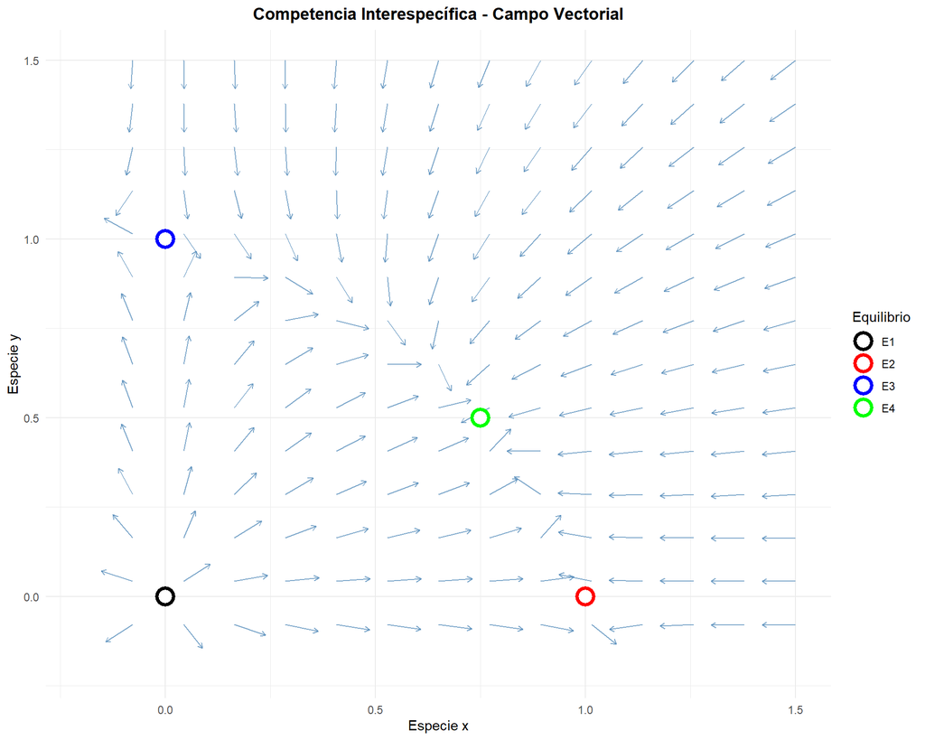

```r
p1 <- graficar_campo(campo_comp,
                     titulo = "Competencia Interespecífica - Campo Vectorial",
                     x_label = "Especie x",
                     y_label = "Especie y") +
  # Añadir puntos de equilibrio
  geom_point(data = equilibrios, aes(x = x, y = y, color = nombre),
             size = 5, shape = 21, fill = "white", stroke = 2) +
  scale_color_manual(values = c("E1" = "black", "E2" = "red", "E3" = "blue", "E4" = "green")) +
  labs(color = "Equilibrio") +
  xlim(-0.2, 1.5) +
  ylim(-0.2, 1.5)

print(p1)
```

### Paso 5: Añadir isoclinas nulas

Las isoclinas nulas son las líneas donde $\frac{dx}{dt} = 0$ o $\frac{dy}{dt} = 0$.

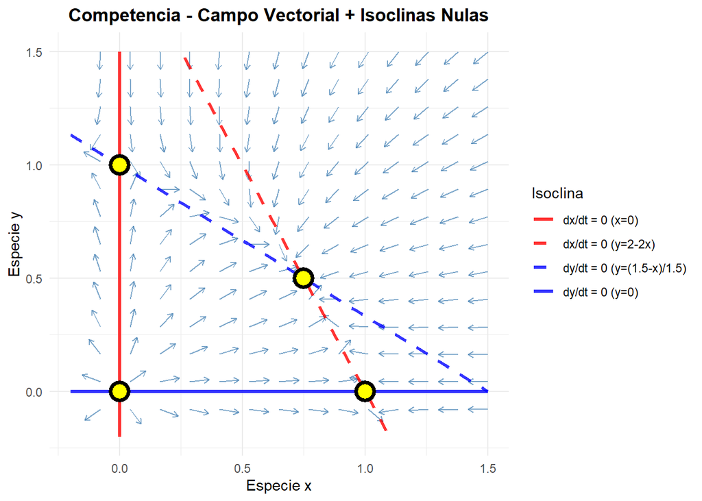

```r
# Isoclinas nulas para dx/dt = 0:
# x(2 - 2x - y) = 0
# x = 0 o 2 - 2x - y = 0 => y = 2 - 2x

# Isoclinas nulas para dy/dt = 0:
# y(1.5 - x - 1.5y) = 0
# y = 0 o 1.5 - x - 1.5y = 0 => y = (1.5 - x) / 1.5

# Crear datos para las isoclinas
x_iso <- seq(-0.2, 1.5, length.out = 100)
isoclina_x1 <- data.frame(x = 0, y = seq(-0.2, 1.5, length.out = 100), tipo = "dx/dt = 0 (x=0)")
isoclina_x2 <- data.frame(x = x_iso, y = 2 - 2*x_iso, tipo = "dx/dt = 0 (y=2-2x)")
isoclina_y1 <- data.frame(x = seq(-0.2, 1.5, length.out = 100), y = 0, tipo = "dy/dt = 0 (y=0)")
isoclina_y2 <- data.frame(x = x_iso, y = (1.5 - x_iso) / 1.5, tipo = "dy/dt = 0 (y=(1.5-x)/1.5)")

isoclinas <- rbind(isoclina_x1, isoclina_x2, isoclina_y1, isoclina_y2)

# Graficar con isoclinas
p2 <- graficar_campo(campo_comp,
                     titulo = "Competencia - Campo Vectorial + Isoclinas Nulas",
                     x_label = "Especie x",
                     y_label = "Especie y") +
  # Añadir isoclinas
  geom_line(data = isoclinas, aes(x = x, y = y, color = tipo, linetype = tipo),
            size = 1.2, alpha = 0.8) +
  scale_color_manual(values = c("dx/dt = 0 (x=0)" = "red",
                                "dx/dt = 0 (y=2-2x)" = "red",
                                "dy/dt = 0 (y=0)" = "blue",
                                "dy/dt = 0 (y=(1.5-x)/1.5)" = "blue")) +
  scale_linetype_manual(values = c("dx/dt = 0 (x=0)" = "solid",
                                   "dx/dt = 0 (y=2-2x)" = "dashed",
                                   "dy/dt = 0 (y=0)" = "solid",
                                   "dy/dt = 0 (y=(1.5-x)/1.5)" = "dashed")) +
  # Añadir puntos de equilibrio
  geom_point(data = equilibrios, aes(x = x, y = y),
             color = "black", size = 5, shape = 21, fill = "yellow", stroke = 2) +
  xlim(-0.2, 1.5) +
  ylim(-0.2, 1.5) +
  labs(color = "Isoclina", linetype = "Isoclina")

print(p2)
```

### Paso 6: Simular trayectorias

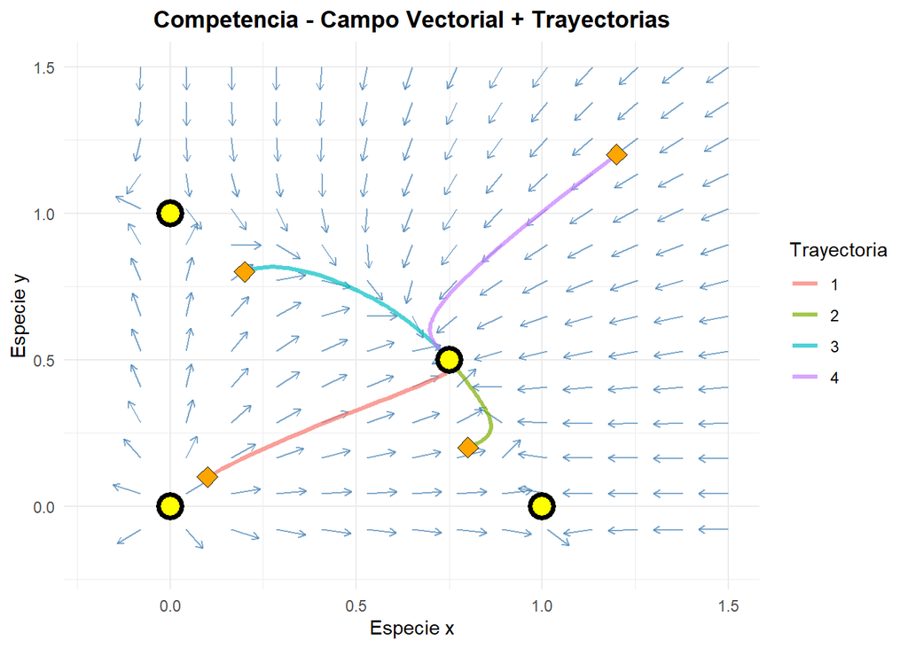

```r
# Definir el modelo para deSolve
modelo_comp <- function(time, state, parameters) {
  with(as.list(c(state, parameters)), {
    dx <- x * (2 - 2*x - y)
    dy <- y * (1.5 - x - 1.5*y)
    return(list(c(dx, dy)))
  })
}

# Simular desde varios puntos iniciales
puntos_iniciales <- list(
  c(0.1, 0.1),
  c(0.8, 0.2),
  c(0.2, 0.8),
  c(1.2, 1.2)
)

# Resolver para cada punto inicial
trayectorias <- data.frame()
for (i in seq_along(puntos_iniciales)) {
  y0 <- puntos_iniciales[[i]]
  sol <- ode(y = c(x = y0[1], y = y0[2]),
             times = seq(0, 50, by = 0.1),
             func = modelo_comp,
             parms = NULL)

  sol_df <- as.data.frame(sol)
  sol_df$trayectoria <- i
  trayectorias <- rbind(trayectorias, sol_df)
}

# Graficar con trayectorias
p3 <- graficar_campo(campo_comp,
                     titulo = "Competencia - Campo Vectorial + Trayectorias",
                     x_label = "Especie x",
                     y_label = "Especie y") +
  # Añadir trayectorias
  geom_path(data = trayectorias, aes(x = x, y = y, color = factor(trayectoria)),
            size = 1.2, alpha = 0.7) +
  # Añadir puntos iniciales
  geom_point(data = data.frame(x = sapply(puntos_iniciales, `[`, 1),
                               y = sapply(puntos_iniciales, `[`, 2)),
             color = "black", size = 4, shape = 23, fill = "orange") +
  # Añadir puntos de equilibrio
  geom_point(data = equilibrios, aes(x = x, y = y),
             color = "black", size = 5, shape = 21, fill = "yellow", stroke = 2) +
  xlim(-0.2, 1.5) +
  ylim(-0.2, 1.5) +
  labs(color = "Trayectoria") +
  theme(legend.position = "right")

print(p3)
```

## Ejercicio 2: Depredador-Presa (Lotka-Volterra Clásico)

**Sistema:**
$$\frac{dx}{dt}
= x(\lambda - by)$$
$$\frac{dy}{dt} =
y(-\mu + cx)$$

Parámetros: $\lambda = 0.5$, $b = 0.02$, $\mu = 0.4$, $c = 0.01$.

### Definir y visualizar

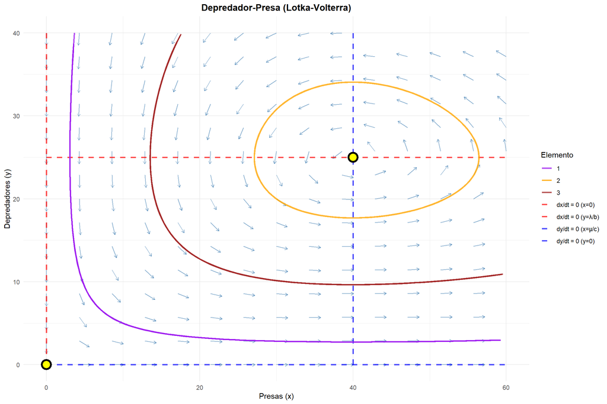

```r
# Parámetros
lambda <- 0.5; b <- 0.02; mu <- 0.4; c <- 0.01

# Funciones
dx_lv <- function(x, y) {
  x * (lambda - b*y)
}

dy_lv <- function(x, y) {
  y * (-mu + c*x)
}

# Puntos de equilibrio
eq_lv <- data.frame(
  nombre = c("E1", "E2"),
  x = c(0, mu/c),
  y = c(0, lambda/b)
)

# Campo vectorial
campo_lv <- crear_campo_vectorial(
  dx_func = dx_lv,
  dy_func = dy_lv,
  x_range = c(0, 60),
  y_range = c(0, 40),
  n_points = 15,
  escala = 1.5
)

# Isoclinas
x_iso_lv <- seq(0, 60, length.out = 100)
isoclinas_lv <- data.frame(
  x = c(rep(0, 100), x_iso_lv),
  y = c(seq(0, 40, length.out = 100), rep(lambda/b, 100)),
  tipo = c(rep("dx/dt = 0 (x=0)", 100), rep("dx/dt = 0 (y=λ/b)", 100))
)

isoclinas_lv2 <- data.frame(
  x = c(rep(mu/c, 100), seq(0, 60, length.out = 100)),
  y = c(seq(0, 40, length.out = 100), rep(0, 100)),
  tipo = c(rep("dy/dt = 0 (x=μ/c)", 100), rep("dy/dt = 0 (y=0)", 100))
)

isoclinas_lv <- rbind(isoclinas_lv, isoclinas_lv2)

# Simular trayectorias
puntos_ini_lv <- list(c(10, 5), c(30, 20), c(50, 10))
trayectorias_lv <- data.frame()

modelo_lv <- function(time, state, parameters) {
  with(as.list(c(state, parameters)), {
    dx <- x * (lambda - b*y)
    dy <- y * (-mu + c*x)
    return(list(c(dx, dy)))
  })
}

for (i in seq_along(puntos_ini_lv)) {
  y0 <- puntos_ini_lv[[i]]
  sol <- ode(y = c(x = y0[1], y = y0[2]),
             times = seq(0, 100, by = 0.1),
             func = modelo_lv,
             parms = c(lambda = lambda, b = b, mu = mu, c = c))

  sol_df <- as.data.frame(sol)
  sol_df$trayectoria <- i
  trayectorias_lv <- rbind(trayectorias_lv, sol_df)
}

# Graficar
p_lv <- graficar_campo(campo_lv,
                       titulo = "Depredador-Presa (Lotka-Volterra)",
                       x_label = "Presas (x)",
                       y_label = "Depredadores (y)") +
  geom_line(data = isoclinas_lv, aes(x = x, y = y, color = tipo),
            size = 1, alpha = 0.7, linetype = "dashed") +
  geom_path(data = trayectorias_lv, aes(x = x, y = y, color = factor(trayectoria)),
            size = 1, alpha = 0.8) +
  geom_point(data = eq_lv, aes(x = x, y = y),
             color = "black", size = 5, shape = 21, fill = "yellow", stroke = 2) +
  scale_color_manual(values = c("dx/dt = 0 (x=0)" = "red",
                                "dx/dt = 0 (y=λ/b)" = "red",
                                "dy/dt = 0 (x=μ/c)" = "blue",
                                "dy/dt = 0 (y=0)" = "blue",
                                "1" = "purple", "2" = "orange", "3" = "brown")) +
  xlim(0, 60) +
  ylim(0, 40) +
  labs(color = "Elemento")

print(p_lv)
```

## Ejercicio 3: Modelo del Quimiostato

**Sistema:**
$$\frac{dy}{dt}
= r(C)y - qy$$
$$\frac{dC}{dt} =
q(C^{(0)} - C) - \beta r(C)y$$

Donde $r(C) = \frac{aC}{C+A}$ (Función de Monod).

### Definir y visualizar

```r
# Parámetros
a <- 1.2; A <- 0.5; q <- 0.5; C0 <- 10; beta <- 2

# Función de Monod
r_monod <- function(C) {
  (a * C) / (C + A)
}

# Funciones del sistema
dy_chem <- function(y, C) {
  r_monod(C) * y - q * y
}

dC_chem <- function(y, C) {
  q * (C0 - C) - beta * r_monod(C) * y
}

# Puntos de equilibrio (calculados numéricamente)
# En equilibrio: r(C*) = q => (a*C*)/(C*+A) = q
# Resolviendo: C* = A*q/(a-q)
C_star <- A * q / (a - q)
# De la segunda ecuación: q(C0 - C*) = beta*r(C*)*y*
# y* = q(C0 - C*) / (beta*r(C*))
y_star <- q * (C0 - C_star) / (beta * r_monod(C_star))

eq_chem <- data.frame(
  nombre = "E*",
  y = y_star,
  C = C_star
)

cat("Equilibrio: y* =", y_star, ", C* =", C_star, "\n")
```

```
## Equilibrio: y* = 4.821429 , C* = 0.3571429
```

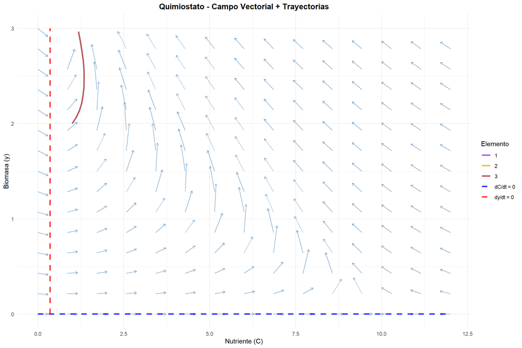

```r
# Campo vectorial
campo_chem <- crear_campo_vectorial(
  dx_func = function(C, y) dC_chem(y, C),
  dy_func = function(C, y) dy_chem(y, C),
  x_range = c(0, 12),
  y_range = c(0, 3),
  n_points = 15,
  escala = 0.3
)

# Renombrar para consistencia
colnames(campo_chem) <- c("C", "y", "dC", "dy", "dC_norm", "dy_norm")

# Isoclinas
C_iso <- seq(0, 12, length.out = 100)
# dy/dt = 0: r(C) = q => (a*C)/(C+A) = q
# Resolviendo: C = A*q/(a-q) (línea vertical)
isoclinas_chem <- data.frame(
  C = c(rep(C_star, 100), C_iso),
  y = c(seq(0, 3, length.out = 100), rep(0, 100)),
  tipo = c(rep("dy/dt = 0", 100), rep("dC/dt = 0", 100))
)

# Simular trayectorias
puntos_ini_chem <- list(c(10, 0.1), c(5, 2), c(2, 1))
trayectorias_chem <- data.frame()

modelo_chem <- function(time, state, parameters) {
  with(as.list(c(state, parameters)), {
    r_C <- (a * C) / (C + A)
    dy <- r_C * y - q * y
    dC <- q * (C0 - C) - beta * r_C * y
    return(list(c(dy, dC)))
  })
}

for (i in seq_along(puntos_ini_chem)) {
  y0 <- puntos_ini_chem[[i]]
  sol <- ode(y = c(y = y0[1], C = y0[2]),
             times = seq(0, 30, by = 0.1),
             func = modelo_chem,
             parms = c(a = a, A = A, q = q, C0 = C0, beta = beta))

  sol_df <- as.data.frame(sol)
  sol_df$trayectoria <- i
  trayectorias_chem <- rbind(trayectorias_chem, sol_df)
}

# Graficar
p_chem <- ggplot(campo_chem, aes(x = C, y = y)) +
  geom_segment(aes(xend = C + dC_norm, yend = y + dy_norm),
               arrow = arrow(length = unit(0.15, "cm")),
               color = "steelblue", alpha = 0.7) +
  geom_line(data = isoclinas_chem, aes(x = C, y = y, color = tipo),
            size = 1.2, alpha = 0.8, linetype = "dashed") +
  geom_path(data = trayectorias_chem, aes(x = C, y = y, color = factor(trayectoria)),
            size = 1.2, alpha = 0.8) +
  geom_point(data = eq_chem, aes(x = C, y = y),
             color = "black", size = 6, shape = 21, fill = "yellow", stroke = 2) +
  scale_color_manual(values = c("dy/dt = 0" = "red", "dC/dt = 0" = "blue",
                                "1" = "purple", "2" = "orange", "3" = "brown")) +
  labs(title = "Quimiostato - Campo Vectorial + Trayectorias",
       x = "Nutriente (C)",
       y = "Biomasa (y)",
       color = "Elemento") +
  xlim(0, 12) +
  ylim(0, 3) +
  theme_minimal() +
  theme(plot.title = element_text(hjust = 0.5, face = "bold"))

print(p_chem)
```

## Ejercicio 4: Tu Turno - Modelo SIR

Crea un análisis completo del modelo SIR:

$$\frac{dS}{dt} = -\beta S I$$
$$\frac{dI}{dt} = \beta S I - \gamma
I$$

Con parámetros: $\beta = 0.0005$, $\gamma = 0.1$, población total $N = 1000$.

```r
# Parámetros
beta <- 0.0005
gamma <- 0.1
N <- 1000

# Define las funciones dS/dt y dI/dt
dS_sir <- function(S, I) {
  # Tu código aquí
}

dI_sir <- function(S, I) {
  # Tu código aquí
}

# Encuentra los puntos de equilibrio
# Tu análisis aquí

# Crea el campo vectorial
# Tu código aquí

# Simula trayectorias
# Tu código aquí

# Grafica todo junto
# Tu código aquí
```

## Resumen de Funciones Útiles

```r
# Crear campo vectorial
crear_campo_vectorial <- function(dx_func, dy_func, x_range, y_range,
                                  n_points = 15, escala = 0.5) {
  # Crea una malla de puntos y calcula derivadas
}

# Graficar campo
graficar_campo <- function(campo_df, titulo = "", x_label = "x", y_label = "y") {
  # Visualiza el campo vectorial con ggplot2
}

# Resolver ODE (ejemplo)
model <- function(time, state, parameters) {
  with(as.list(c(state, parameters)), {
    dx <- ... # tu ecuación
    dy <- ... # tu ecuación
    return(list(c(dx, dy)))
  })
}

# Resolver numéricamente
out <- ode(y = c(x = 1, y = 1), times = seq(0, 100, by = 0.1),
           func = model, parms = c())
```

## Consejos Prácticos

1. **Ajusta la escala:** Si las flechas son muy grandes o pequeñas, modifica el parámetro `escala` en `crear_campo_vectorial()`.
2. **Número de puntos:** Aumenta `n_points` para un campo más denso (pero más lento).
3. **Colores:** Personaliza los colores modificando los valores en `scale_color_manual()`.
4. **Tiempo de simulación:** Aumenta el tiempo en `seq(0, T, by = dt)` para ver más dinámica.
5. **Puntos iniciales:** Experimenta con diferentes puntos iniciales para entender la estructura del sistema.